# Chocolate Flavored Exploratory Data Analysis

Rebecca Hadi

February 3rd, 2018

As a chocolate lover, when I saw this chocolate related data set on Kaggle, I couldn’t resist the temptation to play around and see what I could learn. This notebook will walk through my typical steps of exploring a new data set. For reference, the data I’m working with can be found at https://www.kaggle.com/rtatman/chocolate-bar-ratings/data.

I’ve loaded the packages ggplot2, dplyr, and tidyr (code not shown).

First, I will load the data.

Next, I want to look at the data itself, the structure/format, and summary values.

```
 Company...Maker.if.known.   Specific.Bean.Origin.or.Bar.Name      REF        Review.Date
 Soma    :  47             Madagascar        :  57            Min.   :   5   Min.   :2006
 Bonnat  :  27             Peru              :  45            1st Qu.: 576   1st Qu.:2010
 Fresco  :  26             Ecuador           :  42            Median :1069   Median :2013
 Pralus  :  25             Dominican Republic:  37            Mean   :1036   Mean   :2012
 A. Morin:  23             Venezuela         :  21            3rd Qu.:1502   3rd Qu.:2015
 Arete   :  22             Chuao             :  19            Max.   :1952   Max.   :2017
 (Other) :1625             (Other)           :1574
 Cocoa.Percent Company.Location     Rating                     Bean.Type
 70%    :672   U.S.A. :764      Min.   :1.000                       :887
 75%    :222   France :156      1st Qu.:2.875   Trinitario          :419
 72%    :189   Canada :125      Median :3.250   Criollo             :153
 65%    : 78   U.K.   : 96      Mean   :3.186   Forastero           : 87
 80%    : 72   Italy  : 63      3rd Qu.:3.500   Forastero (Nacional): 52
 74%    : 50   Ecuador: 54      Max.   :5.000   Blend               : 41
 (Other):512   (Other):537                      (Other)             :156
          Broad.Bean.Origin
 Venezuela         :214
 Ecuador           :193
 Peru              :165
 Madagascar        :145
 Dominican Republic:141
                   : 73
 (Other)           :864
```

It’s interesting that the Cocoa percent is stored as a factor opposed to a numeric value. Let’s create another column that has the data stored as numeric.

Next, I want to look at the relationship between some of the variables. First, I’m interested in the relationship between cocoa percentage and rating.

### What’s the relationship between rating and cocoa percent?

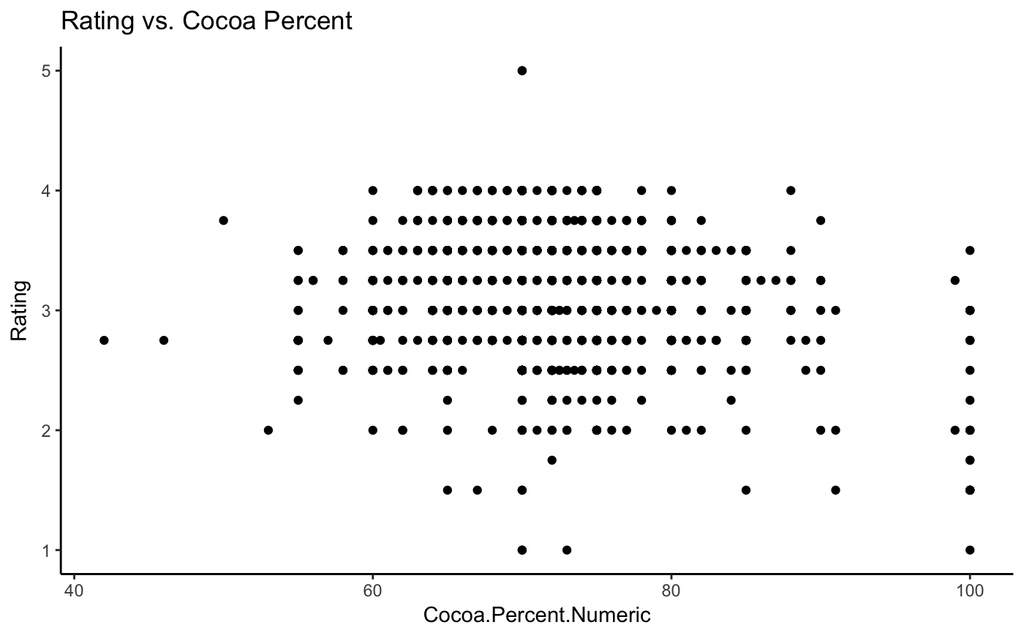

Looking at the plot, there doesn’t appear to be a strong relationship between rating and cocoa percent. We could fit a linear model to validate this. At around 70% cocoa, which has several data points, there is a wide distribution of ratings between 1-5.

```
Call:
lm(formula = Rating ~ Cocoa.Percent.Numeric, data = chocolate)

Residuals:
    Min      1Q  Median      3Q     Max
-2.2071 -0.3196  0.0429  0.3178  1.7929

Coefficients:
                       Estimate Std. Error t value Pr(>|t|)
(Intercept)            4.079388   0.126757  32.183  < 2e-16 ***
Cocoa.Percent.Numeric -0.012461   0.001761  -7.076 2.12e-12 ***
---
Signif. codes:  0 ‘***’ 0.001 ‘**’ 0.01 ‘*’ 0.05 ‘.’ 0.1 ‘ ’ 1

Residual standard error: 0.4717 on 1793 degrees of freedom
Multiple R-squared:  0.02717,   Adjusted R-squared:  0.02662
F-statistic: 50.07 on 1 and 1793 DF,  p-value: 2.122e-12
```

This isn’t the most intuitive coefficient to interpret because we can’t have a cocoa percent of zero (maybe that’s possible somewhere, but not in this data set.) Let’s try it again and re-scale the cocoa percent to centered around the mean.

```r
#Center and scale model by mean and standard deviation respectively
cocoa.rating.z <- (chocolate$Cocoa.Percent.Numeric - mean(chocolate$Cocoa.Percent.Numeric)) / sd(chocolate$Cocoa.Percent.Numeric)

#Fit Model with centered variable
chocolate_model.z <- lm(Rating ~ cocoa.rating.z, data = chocolate)
#Show model
summary(chocolate_model.z)
```

```
Call:
lm(formula = Rating ~ cocoa.rating.z, data = chocolate)

Residuals:
    Min      1Q  Median      3Q     Max
-2.2071 -0.3196  0.0429  0.3178  1.7929

Coefficients:
               Estimate Std. Error t value Pr(>|t|)
(Intercept)     3.18593    0.01113 286.183  < 2e-16 ***
cocoa.rating.z -0.07879    0.01114  -7.076 2.12e-12 ***
---
Signif. codes:  0 ‘***’ 0.001 ‘**’ 0.01 ‘*’ 0.05 ‘.’ 0.1 ‘ ’ 1

Residual standard error: 0.4717 on 1793 degrees of freedom
Multiple R-squared:  0.02717,   Adjusted R-squared:  0.02662
F-statistic: 50.07 on 1 and 1793 DF,  p-value: 2.122e-12
```

For the mean cocoa percentage 71.7$\%$, we predict the rating to be 3.19. The coefficient of the centered cocoa rating is statistically significant. For every 1 standard deviation difference in cocoa rating (which is 6.3231183), we predict the rating to decrease -0.08. This is not a large effect size and we see that the $r^2$ is very low at 0.027, indicating that the model does not do a great job of explaining the variation in our data set.

Now that we’ve seen the data, it makes more sense why the cocoa rating was scored as a factor. I’m curious to see what the most common percentage of cocoa.

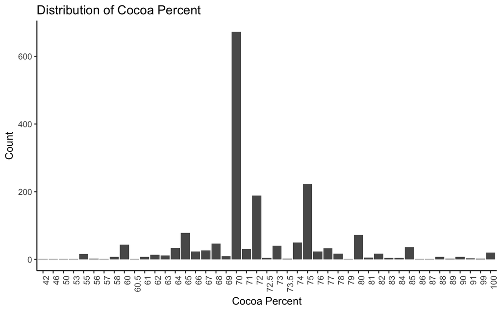

```r
ggplot(data = chocolate, aes(x = as.factor(Cocoa.Percent.Numeric))) +
      geom_bar() +
      theme_classic() +
      ggtitle("Distribution of Cocoa Percent") +
      theme(axis.text.x = element_text(angle = 90, hjust = 1)) +
      labs (x = "Cocoa Percent", y = "Count")
```

Wow! By far, 70% cocoa is the most common in this data set.

There is a lot more we can dig into with this data set (e.g. do any countries produce higher rated chocolate? Is the distribution of cocoa percent similar across all countries?).

For now, I’ve learned that in this data set

1. 70% cocoa is the most common chocolate.
2. There isn’t a strong relationship between cocoa percent and rating.